# Home Price Prediction Project

### Introduction

Thousands of houses are sold everyday. There are some questions every buyer asks himself like: What is the actual price that this house deserves? Am I paying a fair price? In this paper, a machine learning model is proposed to predict a house price based on data related to the house (its size, the year it was built in, etc.). During the development and evaluation of our model, we will show the code used for each step followed by its output. This will facilitate the reproducibility of our work. In this study, Python programming language with a number of Python packages will be used.

Goals of the Study The main objectives of this study are as follows:  
To apply data preprocessing and preparation techniques in order to obtain clean data  
To build machine learning models able to predict house price based on house features  
To analyze and compare models performance in order to choose the best model

```python
import pandas as pd
import matplotlib.pyplot as plt
import seaborn as sns
import numpy as np
from sklearn.model_selection import train_test_split
from sklearn.linear_model import LinearRegression
from sklearn.linear_model import Lasso
from sklearn import metrics
from sklearn.preprocessing import StandardScaler
from sklearn.model_selection import GridSearchCV
from sklearn.linear_model import Ridge
from sklearn.metrics import mean_absolute_error
from sklearn.linear_model import ElasticNet
from sklearn.tree import DecisionTreeRegressor
```

## Import Data Set

```python
#importing data set...
dataset = pd.read_csv('AmesHousing.csv')
dataset.head()
```

|  | Order | PID | MS SubClass | MS Zoning | Lot Frontage | Lot Area | Street | Alley | Lot Shape | Land Contour | ... | Pool Area | Pool QC | Fence | Misc Feature | Misc Val | Mo Sold | Yr Sold | Sale Type | Sale Condition | SalePrice |
| --- | --- | --- | --- | --- | --- | --- | --- | --- | --- | --- | --- | --- | --- | --- | --- | --- | --- | --- | --- | --- | --- |
| 0 | 1 | 526301100 | 20 | RL | 141.0 | 31770 | Pave | NaN | IR1 | Lvl | ... | 0 | NaN | NaN | NaN | 0 | 5 | 2010 | WD | Normal | 215000 |
| 1 | 2 | 526350040 | 20 | RH | 80.0 | 11622 | Pave | NaN | Reg | Lvl | ... | 0 | NaN | MnPrv | NaN | 0 | 6 | 2010 | WD | Normal | 105000 |
| 2 | 3 | 526351010 | 20 | RL | 81.0 | 14267 | Pave | NaN | IR1 | Lvl | ... | 0 | NaN | NaN | Gar2 | 12500 | 6 | 2010 | WD | Normal | 172000 |
| 3 | 4 | 526353030 | 20 | RL | 93.0 | 11160 | Pave | NaN | Reg | Lvl | ... | 0 | NaN | NaN | NaN | 0 | 4 | 2010 | WD | Normal | 244000 |
| 4 | 5 | 527105010 | 60 | RL | 74.0 | 13830 | Pave | NaN | IR1 | Lvl | ... | 0 | NaN | MnPrv | NaN | 0 | 3 | 2010 | WD | Normal | 189900 |

5 rows × 82 columns

```python
dataset.describe(include=[np.number], percentiles=[.5]) \
    .transpose()
```

|  | count | mean | std | min | 50% | max |
| --- | --- | --- | --- | --- | --- | --- |
| Order | 2930.0 | 1.465500e+03 | 8.459625e+02 | 1.0 | 1465.5 | 2.930000e+03 |
| PID | 2930.0 | 7.144645e+08 | 1.887308e+08 | 526301100.0 | 535453620.0 | 1.007100e+09 |
| MS SubClass | 2930.0 | 5.738737e+01 | 4.263802e+01 | 20.0 | 50.0 | 1.900000e+02 |
| Lot Frontage | 2440.0 | 6.922459e+01 | 2.336533e+01 | 21.0 | 68.0 | 3.130000e+02 |
| Lot Area | 2930.0 | 1.014792e+04 | 7.880018e+03 | 1300.0 | 9436.5 | 2.152450e+05 |
| Overall Qual | 2930.0 | 6.094881e+00 | 1.411026e+00 | 1.0 | 6.0 | 1.000000e+01 |
| Overall Cond | 2930.0 | 5.563140e+00 | 1.111537e+00 | 1.0 | 5.0 | 9.000000e+00 |
| Year Built | 2930.0 | 1.971356e+03 | 3.024536e+01 | 1872.0 | 1973.0 | 2.010000e+03 |
| Year Remod/Add | 2930.0 | 1.984267e+03 | 2.086029e+01 | 1950.0 | 1993.0 | 2.010000e+03 |
| Mas Vnr Area | 2907.0 | 1.018968e+02 | 1.791126e+02 | 0.0 | 0.0 | 1.600000e+03 |
| BsmtFin SF 1 | 2929.0 | 4.426296e+02 | 4.555908e+02 | 0.0 | 370.0 | 5.644000e+03 |
| BsmtFin SF 2 | 2929.0 | 4.972243e+01 | 1.691685e+02 | 0.0 | 0.0 | 1.526000e+03 |
| Bsmt Unf SF | 2929.0 | 5.592625e+02 | 4.394942e+02 | 0.0 | 466.0 | 2.336000e+03 |
| Total Bsmt SF | 2929.0 | 1.051615e+03 | 4.406151e+02 | 0.0 | 990.0 | 6.110000e+03 |
| 1st Flr SF | 2930.0 | 1.159558e+03 | 3.918909e+02 | 334.0 | 1084.0 | 5.095000e+03 |
| 2nd Flr SF | 2930.0 | 3.354560e+02 | 4.283957e+02 | 0.0 | 0.0 | 2.065000e+03 |
| Low Qual Fin SF | 2930.0 | 4.676792e+00 | 4.631051e+01 | 0.0 | 0.0 | 1.064000e+03 |
| Gr Liv Area | 2930.0 | 1.499690e+03 | 5.055089e+02 | 334.0 | 1442.0 | 5.642000e+03 |
| Bsmt Full Bath | 2928.0 | 4.313525e-01 | 5.248202e-01 | 0.0 | 0.0 | 3.000000e+00 |
| Bsmt Half Bath | 2928.0 | 6.113388e-02 | 2.452536e-01 | 0.0 | 0.0 | 2.000000e+00 |
| Full Bath | 2930.0 | 1.566553e+00 | 5.529406e-01 | 0.0 | 2.0 | 4.000000e+00 |
| Half Bath | 2930.0 | 3.795222e-01 | 5.026293e-01 | 0.0 | 0.0 | 2.000000e+00 |
| Bedroom AbvGr | 2930.0 | 2.854266e+00 | 8.277311e-01 | 0.0 | 3.0 | 8.000000e+00 |
| Kitchen AbvGr | 2930.0 | 1.044369e+00 | 2.140762e-01 | 0.0 | 1.0 | 3.000000e+00 |
| TotRms AbvGrd | 2930.0 | 6.443003e+00 | 1.572964e+00 | 2.0 | 6.0 | 1.500000e+01 |
| Fireplaces | 2930.0 | 5.993174e-01 | 6.479209e-01 | 0.0 | 1.0 | 4.000000e+00 |
| Garage Yr Blt | 2771.0 | 1.978132e+03 | 2.552841e+01 | 1895.0 | 1979.0 | 2.207000e+03 |
| Garage Cars | 2929.0 | 1.766815e+00 | 7.605664e-01 | 0.0 | 2.0 | 5.000000e+00 |
| Garage Area | 2929.0 | 4.728197e+02 | 2.150465e+02 | 0.0 | 480.0 | 1.488000e+03 |
| Wood Deck SF | 2930.0 | 9.375188e+01 | 1.263616e+02 | 0.0 | 0.0 | 1.424000e+03 |
| Open Porch SF | 2930.0 | 4.753345e+01 | 6.748340e+01 | 0.0 | 27.0 | 7.420000e+02 |
| Enclosed Porch | 2930.0 | 2.301160e+01 | 6.413906e+01 | 0.0 | 0.0 | 1.012000e+03 |
| 3Ssn Porch | 2930.0 | 2.592491e+00 | 2.514133e+01 | 0.0 | 0.0 | 5.080000e+02 |
| Screen Porch | 2930.0 | 1.600205e+01 | 5.608737e+01 | 0.0 | 0.0 | 5.760000e+02 |
| Pool Area | 2930.0 | 2.243345e+00 | 3.559718e+01 | 0.0 | 0.0 | 8.000000e+02 |
| Misc Val | 2930.0 | 5.063515e+01 | 5.663443e+02 | 0.0 | 0.0 | 1.700000e+04 |
| Mo Sold | 2930.0 | 6.216041e+00 | 2.714492e+00 | 1.0 | 6.0 | 1.200000e+01 |
| Yr Sold | 2930.0 | 2.007790e+03 | 1.316613e+00 | 2006.0 | 2008.0 | 2.010000e+03 |
| SalePrice | 2930.0 | 1.807961e+05 | 7.988669e+04 | 12789.0 | 160000.0 | 7.550000e+05 |

```python
# Getting the number of missing values in each column
num_missing = dataset.isna().sum()

# Excluding columns that contains 0 missing values
num_missing = num_missing[num_missing > 0]

# Getting the percentages of missing values
percent_missing = num_missing * 100 / dataset.shape[0]

# Concatenating the number and perecentage of missing values
# into one dataframe and sorting it
pd.concat([num_missing, percent_missing], axis=1,
          keys=['Missing Values', 'Percentage']).\
          sort_values(by="Missing Values", ascending=False)
```

|  | Missing Values | Percentage |
| --- | --- | --- |
| Pool QC | 2917 | 99.556314 |
| Misc Feature | 2824 | 96.382253 |
| Alley | 2732 | 93.242321 |
| Fence | 2358 | 80.477816 |
| Fireplace Qu | 1422 | 48.532423 |
| Lot Frontage | 490 | 16.723549 |
| Garage Cond | 159 | 5.426621 |
| Garage Qual | 159 | 5.426621 |
| Garage Finish | 159 | 5.426621 |
| Garage Yr Blt | 159 | 5.426621 |
| Garage Type | 157 | 5.358362 |
| Bsmt Exposure | 83 | 2.832765 |
| BsmtFin Type 2 | 81 | 2.764505 |
| BsmtFin Type 1 | 80 | 2.730375 |
| Bsmt Qual | 80 | 2.730375 |
| Bsmt Cond | 80 | 2.730375 |
| Mas Vnr Area | 23 | 0.784983 |
| Mas Vnr Type | 23 | 0.784983 |
| Bsmt Half Bath | 2 | 0.068259 |
| Bsmt Full Bath | 2 | 0.068259 |
| Total Bsmt SF | 1 | 0.034130 |
| Bsmt Unf SF | 1 | 0.034130 |
| Garage Cars | 1 | 0.034130 |
| Garage Area | 1 | 0.034130 |
| BsmtFin SF 2 | 1 | 0.034130 |
| BsmtFin SF 1 | 1 | 0.034130 |
| Electrical | 1 | 0.034130 |

Data Description The dataset contains 2930 records (rows) and 82 features (columns).

Here, we will provide a brief description of dataset features.

Feature Description Overview MSSubClass: The type of the house involved in the sale  
MSZoning: The general zoning classification of the sale  
LotFrontage: Linear feet of street connected to the house  
LotArea: Lot size in square feet  
Street: Type of road access to the house  
Alley: Type of alley access to the house  
LotShape: General shape of the house  
LandContour: House flatness  
Utilities: Type of utilities available  
LotConfig: Lot configuration  
LandSlope: House Slope  
Neighborhood: Locations within Ames city limits  
Condition1: Proximity to various conditions  
Condition2: Proximity to various conditions (if more than one is present)  
BldgType: House type  
HouseStyle: House style  
OverallQual: Overall quality of material and finish of the house  
OverallCond: Overall condition of the house  
Etc...

#### Handling Null Values

Now we start dealing with these missing values.

Pool QC The percentage of missing values in Pool QC column is 99.56% which is very high. We think that a missing value in this column denotes that the corresponding house doesn't have a pool. To verify this, let's take a look at the values of Pool Area column:

```python
dataset["Pool Area"].value_counts()
```

```
0      2917
144       1
228       1
368       1
444       1
480       1
512       1
576       1
648       1
738       1
800       1
519       1
555       1
561       1
Name: Pool Area, dtype: int64
```

[interactive chart not shown]

We can see that there are 2917 entries in Pool Area column that have a value of 0. This verfies our hypothesis that each house without a pool has a missing value in Pool QC column and a value of 0 in Pool Area column. So let's fill the missing values in Pool QC column with "No Pool":

```python
dataset["Pool QC"].fillna("No Pool", inplace=True)
```

```python
dataset["Misc Val"].value_counts()
```

[output not shown]

We can see that Misc Val column has 2827 entries with a value of 0. Misc Feature has 2824 missing values. Then, as with Pool QC, we can say that each house without a "miscellaneous feature" has a missing value in Misc Feature column and a value of 0 in Misc Val column. So let's fill the missing values in Misc Feature column with "No Feature":

```python
dataset['Misc Feature'].fillna('No feature', inplace=True)
```

Alley, Fence, and Fireplace Qu According to the dataset documentation, NA in Alley, Fence, and Fireplace Qu columns denotes that the house doesn't have an alley, fence, or fireplace. So we fill in the missing values in these columns with "No Alley", "No Fence", and "No Fireplace" accordingly:

```python
dataset['Alley'].fillna('No Alley', inplace=True)
dataset['Fence'].fillna('No Fence', inplace=True)
dataset['Fireplace Qu'].fillna('No Fireplace', inplace=True)
```

Lot Frontage As we saw previously, Lot Frontage represents the linear feet of street connected to the house. So we assume that the missing values in this column indicates that the house is not connected to any street, and we fill in the missing values with 0:

```python
dataset['Lot Frontage'].fillna(0, inplace=True)
```

Garage Cond, Garage Qual, Garage Finish, Garage Yr Blt, Garage Type, Garage Cars, and Garage Area According to the dataset documentation, NA in Garage Cond, Garage Qual, Garage Finish, and Garage Type indicates that there is no garage in the house. So we fill in the missing values in these columns with "No Garage". We notice that Garage Cond, Garage Qual, Garage Finish, Garage Yr Blt columns have 159 missing values, but Garage Type has 157 and both Garage Cars and Garage Area have one missing value. Let's take a look at the row that contains the missing value in Garage Cars:

```python
garage_columns = [col for col in dataset.columns if col.startswith("Garage")]
dataset[dataset['Garage Cars'].isna()][garage_columns]
```

[output not shown]

We can see that this is the same row that contains the missing value in Garage Area, and that all garage columns except Garage Type are null in this row, so we will fill the missing values in Garage Cars and Garage Area with 0.

We saw that there are 2 rows where Garage Type is not null while Garage Cond, Garage Qual, Garage Finish, and Garage Yr Blt columns are null. Let's take a look at these two rows:

```python
dataset[~pd.isna(dataset['Garage Type']) &
        pd.isna(dataset['Garage Qual'])][garage_columns]
```

[output not shown]

We will replace the values of Garage Type with "No Garage" in these two rows also.

For Garage Yr Blt, we will fill in missing values with 0 since this is a numerical column:

```python
dataset['Garage Cars'].fillna(0, inplace=True)
dataset['Garage Area'].fillna(0, inplace=True)

dataset.loc[~pd.isna(dataset['Garage Type']) &
            pd.isna(dataset['Garage Qual']), "Garage Type"] = "No Garage"

for col in ['Garage Type', 'Garage Finish', 'Garage Qual', 'Garage Cond']:
    dataset[col].fillna('No Garage', inplace=True)

dataset['Garage Yr Blt'].fillna(0, inplace=True)
```

Bsmt Exposure, BsmtFin Type 2, BsmtFin Type 1, Bsmt Qual, Bsmt Cond, Bsmt Half Bath, Bsmt Full Bath, Total Bsmt SF, Bsmt Unf SF, BsmtFin SF 2, and BsmtFin SF 1 According to the dataset documentation, NA in any of the first five of these columns indicates that there is no basement in the house. So we fill in the missing values in these columns with "No Basement". We notice that the first five of these columns have 80 missing values, but BsmtFin Type 2 has 81, Bsmt Exposure has 83, Bsmt Half Bath and Bsmt Full Bath each has 2, and each of the others has 1. Let's take a look at the rows where Bsmt Half Bath is null:

```python
bsmt_columns = [col for col in dataset.columns if "Bsmt" in col]
dataset[dataset['Bsmt Half Bath'].isna()][bsmt_columns]
```

[output not shown]

We can see that these are the same rows that contain the missing values in Bsmt Full Bath, and that one of these two rows is contains the missing value in each of Total Bsmt SF, Bsmt Unf SF, BsmtFin SF 2, and BsmtFin SF 1 columns. We notice also that Bsmt Exposure, BsmtFin Type 2, BsmtFin Type 1, Bsmt Qual, and Bsmt Cond are null in these rows, so we will fill the missing values in Bsmt Half Bath, Bsmt Full Bath, Total Bsmt SF, Bsmt Unf SF, BsmtFin SF 2, and BsmtFin SF 1 columns with 0.

We saw that there are 3 rows where Bsmt Exposure is null while BsmtFin Type 1, Bsmt Qual, and Bsmt Cond are not null. Let's take a look at these three rows:

```python
dataset[~pd.isna(dataset['Bsmt Cond']) & pd.isna(dataset['Bsmt Exposure'])][bsmt_columns]
```

[output not shown]

We will fill in the missing values in Bsmt Exposure for these three rows with "No". According to the dataset documentation, "No" for Bsmt Exposure means "No Exposure":

Let's now take a look at the row where BsmtFin Type 2 is null while BsmtFin Type 1, Bsmt Qual, and Bsmt Cond are not null:

```python
dataset[~pd.isna(dataset['Bsmt Cond']) & pd.isna(dataset['BsmtFin Type 2'])][bsmt_columns]
```

[output not shown]

We will fill in the missing value in BsmtFin Type 2 for this row with "Unf". According to the dataset documentation, "Unf" for BsmtFin Type 2 means "Unfinished":

```python
for col in ["Bsmt Half Bath", "Bsmt Full Bath", "Total Bsmt SF",
            "Bsmt Unf SF", "BsmtFin SF 2", "BsmtFin SF 1"]:
    dataset[col].fillna(0, inplace=True)

dataset.loc[~pd.isna(dataset['Bsmt Cond']) &
            pd.isna(dataset['Bsmt Exposure']), "Bsmt Exposure"] = "No"
dataset.loc[~pd.isna(dataset['Bsmt Cond']) &
            pd.isna(dataset['BsmtFin Type 2']), "BsmtFin Type 2"] = "Unf"

for col in ["Bsmt Exposure", "BsmtFin Type 2",
            "BsmtFin Type 1", "Bsmt Qual", "Bsmt Cond"]:
    dataset[col].fillna("No Basement", inplace=True)
```

Mas Vnr Area and Mas Vnr Type Each of these two columns have 23 missing values. We will fill in these missing values with "None" for Mas Vnr Type and with 0 for Mas Vnr Area. We use "None" for Mas Vnr Type because in the dataset documentation, "None" for Mas Vnr Type means "None" (i.e. no masonry veneer):

```python
dataset['Mas Vnr Area'].fillna(0, inplace=True)
dataset['Mas Vnr Type'].fillna("None", inplace=True)
```

Electrical This column has one missing value. We will fill in this value with the mode of this column:

```python
dataset['Electrical'].fillna(dataset['Electrical'].mode()[0], inplace=True)
```

```python
dataset.isna().values.sum()
```

```
0
```

### Outlier Removal

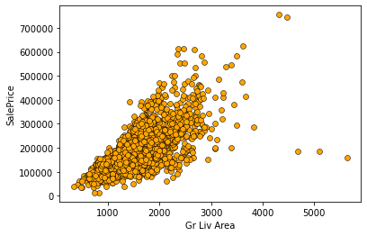

```python
plt.scatter(x=dataset['Gr Liv Area'], y=dataset['SalePrice'],
            color="orange", edgecolors="#000000", linewidths=0.5);
plt.xlabel("Gr Liv Area"); plt.ylabel("SalePrice");
```

```python
outlirt_columns = ["Gr Liv Area"] + \
                  [col for col in dataset.columns if "Sale" in col]
dataset[dataset["Gr Liv Area"] > 4000][outlirt_columns]
```

|  | Gr Liv Area | Sale Type | Sale Condition | SalePrice |
| --- | --- | --- | --- | --- |
| 1498 | 5642 | New | Partial | 160000 |
| 1760 | 4476 | WD | Abnorml | 745000 |
| 1767 | 4316 | WD | Normal | 755000 |
| 2180 | 5095 | New | Partial | 183850 |
| 2181 | 4676 | New | Partial | 184750 |

```python
dataset = dataset[dataset["Gr Liv Area"] < 4000]
```

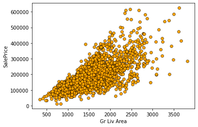

```python
plt.scatter(x=dataset['Gr Liv Area'], y=dataset['SalePrice'],
            color="orange", edgecolors="#000000", linewidths=0.5);
plt.xlabel("Gr Liv Area"); plt.ylabel("SalePrice");
```

```python
#resetting the index
dataset.reset_index(drop=True, inplace=True)
```

```python
# deleting columns that are useful to buildng our model
dataset.drop(['Order', 'PID'], axis=1, inplace=True)
```

### Exploratory Data Analysis

In this section, we will explore the data using visualizations. This will allow us to understand the data and the relationships between variables better, which will help us build a better model.

Target Variable Distribution Our dataset contains a lot of variables, but the most important one for us to explore is the target variable. We need to understand its distribution. First, we start by plotting the violin plot for the target variable. The width of the violin represents the frequency. This means that if a violin is the widest between 300 and 400, then the area between 300 and 400 contains more data points than other areas:

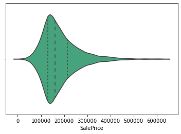

```python
sns.violinplot(x=dataset['SalePrice'], inner="quartile", color="#36B37E");
```

We can see from the plot that most house prices fall between 100,000 and 250,000. The dashed lines represent the locations of the three quartiles Q1, Q2 (the median), and Q3. Now let's see the box plot of SalePrice:

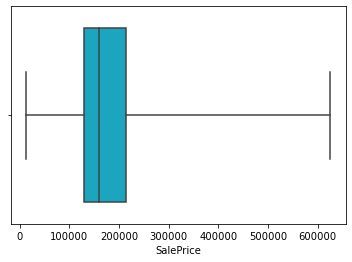

```python
sns.boxplot(dataset['SalePrice'], whis=10, color="#00B8D9");
```

This shows us the minimum and maximum values of SalePrice. It shows us also the three quartiles represented by the box and the vertical line inside of it. Lastly, we plot the histogram of the variable to see a more detailed view of the distribution:

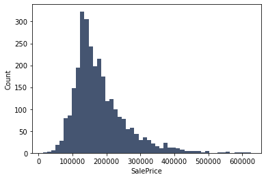

```python
sns.distplot(dataset['SalePrice'], kde=False,
             color="#172B4D", hist_kws={"alpha": 0.8});
plt.ylabel("Count");
```

Correlation Between Variables We want to see how the dataset variables are correlated with each other and how predictor variables are correlated with the target variable. For example, we would like to see how Lot Area and SalePrice are correlated: Do they increase and decrease together (positive correlation)? Does one of them increase when the other decrease or vice versa (negative correlation)? Or are they not correlated?

Correlation is represented as a value between -1 and +1 where +1 denotes the highest positive correlation, -1 denotes the highest negative correlation, and 0 denotes that there is no correlation.

We will show correlation between our dataset variables (numerical and boolean variables only) using a heatmap graph:

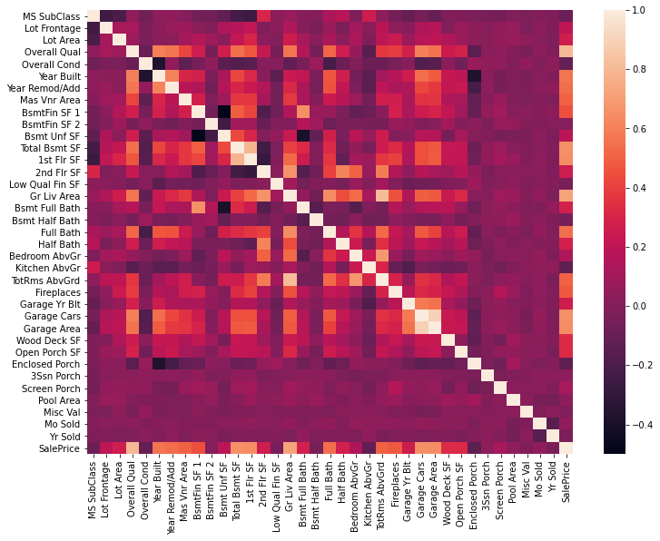

```python
fig, ax = plt.subplots(figsize=(12,9))
sns.heatmap(dataset.corr(), ax=ax);
```

We can see that there are many correlated variables in our dataset. Wwe notice that Garage Cars and Garage Area have high positive correlation which is reasonable because when the garage area increases, its car capacity increases too. We see also that Gr Liv Area and TotRms AbvGrd are highly positively correlated which also makes sense because when living area above ground increases, it is expected for the rooms above ground to increase too.

Regarding negative correlation, we can see that Bsmt Unf SF is negatively correlated with BsmtFin SF 1, and that makes sense because when we have more unfinished area, this means that we have less finished area. We note also that Bsmt Unf SF is negatively correlated with Bsmt Full Bath which is reasonable too.

Most importantly, we want to look at the predictor variables that are correlated with the target variable (SalePrice). By looking at the last row of the heatmap, we see that the target variable is highly positively correlated with Overall Qual and Gr Liv Area. We see also that the target variable is positively correlated with Year Built, Year Remod/Add, Mas Vnr Area, Total Bsmt SF, 1st Flr SF, Full Bath, Garage Cars, and Garage Area.

Relatioships Between the Target Variable and Other Varibles

High Positive Correlation Firstly, we want to visualize the relationships between the target variable and the variables that are highly and positively correlated with it, according to what we saw in the heatmap. Namely, these variables are Overall Qual and Gr Liv Area. We start with the relatioship between the target variable and Overall Qual, but before that, let's see the distribution of each of them. Let's start with the target variable SalePrice:

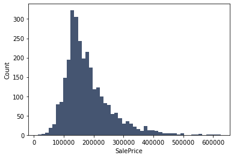

```python
sns.distplot(dataset['SalePrice'], kde=False,
             color="#172B4D", hist_kws={"alpha": 0.8});
plt.ylabel("Count");
```

We can see that most house prices fall between 100,000 and 200,000. We see also that there is a number of expensive houses to the right of the plot. Now, we move to see the distribution of Overall Qual variable:

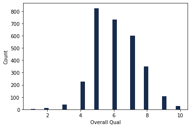

```python
sns.distplot(dataset['Overall Qual'], kde=False,
             color="#172B4D", hist_kws={"alpha": 1});
plt.ylabel("Count");
```

We see that Overall Qual takes an integer value between 1 and 10, and that most houses have an overall quality between 5 and 7. Now we plot the scatter plot of SalePrice and Overall Qual to see the relationship between them:

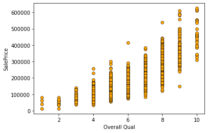

```python
plt.scatter(x=dataset['Overall Qual'], y=dataset['SalePrice'],
            color="orange", edgecolors="#000000", linewidths=0.5);
plt.xlabel("Overall Qual"); plt.ylabel("SalePrice");
```

We can see that they are truly positively correlated; generally, as the overall quality increases, the sale price increases too. This verfies what we got from the heatmap above.

Now, we want to see the relationship between the target variable and Gr Liv Area variable which represents the living area above ground. Let us first see the distribution of Gr Liv Area:

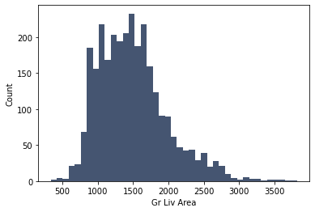

```python
sns.distplot(dataset['Gr Liv Area'], kde=False,
             color="#172B4D", hist_kws={"alpha": 0.8});
plt.ylabel("Count");
```

We can see that the above-ground living area falls approximately between 800 and 1800 ft2. Now, let us see the relationship between Gr Liv Area and the target variable:

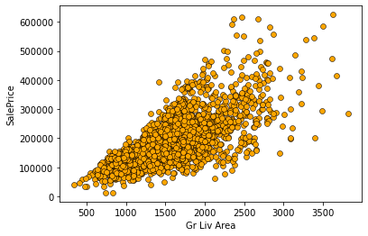

```python
plt.scatter(x=dataset['Gr Liv Area'], y=dataset['SalePrice'],
            color="orange", edgecolors="#000000", linewidths=0.5);
plt.xlabel("Gr Liv Area"); plt.ylabel("SalePrice");
```

The scatter plot above shows clearly the strong positive correlation between Gr Liv Area and SalePrice verifying what we found with the heatmap.

Moderate Positive Correlation Next, we want to visualize the relationship between the target variable and the variables that are positively correlated with it, but the correlation is not very strong. Namely, these variables are Year Built, Year Remod/Add, Mas Vnr Area, Total Bsmt SF, 1st Flr SF, Full Bath, Garage Cars, and Garage Area. We start with the first four. Let us see the distribution of each of them:

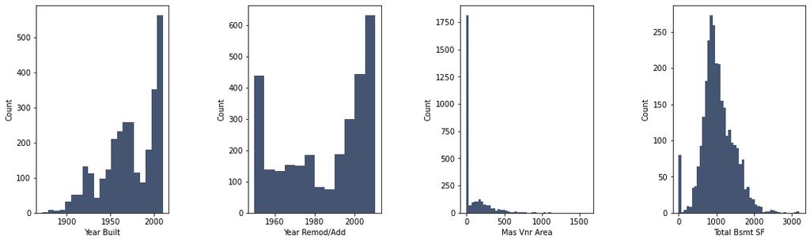

```python
fig, axes = plt.subplots(1, 4, figsize=(18,5))
fig.subplots_adjust(hspace=0.5, wspace=0.6)
for ax, v in zip(axes.flat, ["Year Built", "Year Remod/Add",
                             "Mas Vnr Area", "Total Bsmt SF"]):
    sns.distplot(dataset[v], kde=False, color="#172B4D",
                 hist_kws={"alpha": 0.8}, ax=ax)
    ax.set(ylabel="Count");
```

Now let us see their relationships with the target variable using scatter plots:

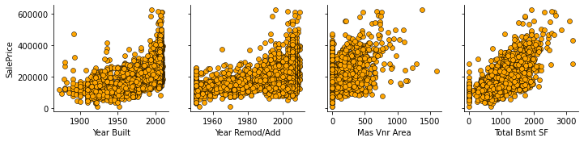

```python
x_vars = ["Year Built", "Year Remod/Add", "Mas Vnr Area", "Total Bsmt SF"]
g = sns.PairGrid(dataset, y_vars=["SalePrice"], x_vars=x_vars);
g.map(plt.scatter, color="orange", edgecolors="#000000", linewidths=0.5);
```

Next, we move to the last four. Let us see the distribution of each of them:

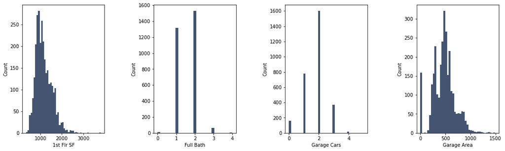

```python
fig, axes = plt.subplots(1, 4, figsize=(18,5))
fig.subplots_adjust(hspace=0.5, wspace=0.6)
for ax, v in zip(axes.flat, ["1st Flr SF", "Full Bath",
                             "Garage Cars", "Garage Area"]):
    sns.distplot(dataset[v], kde=False, color="#172B4D",
                 hist_kws={"alpha": 0.8}, ax=ax);
    ax.set(ylabel="Count");
```

And now let us see their relationships with the target variable:

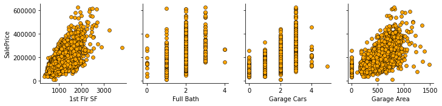

```python
x_vars = ["1st Flr SF", "Full Bath", "Garage Cars", "Garage Area"]
g = sns.PairGrid(dataset, y_vars=["SalePrice"], x_vars=x_vars);
g.map(plt.scatter, color="orange", edgecolors="#000000", linewidths=0.5);
```

From the plots above, we can see that these eight variables are truly positively correlated with the target variable. However, it's apparent that they are not as highly correlated as Overall Qual and Gr Liv Area.

Relatioships Between Predictor Variables

Positive Correlation Apart from the target variable, when we plotted the heatmap, we discovered a high positive correlation between Garage Cars and Garage Area and between Gr Liv Area and TotRms AbvGrd. We want to visualize these correlations also. We've already seen the distribution of each of them except for TotRms AbvGrd. Let us see the distribution of TotRms AbvGrd first:

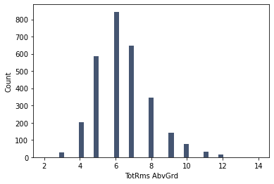

```python
sns.distplot(dataset['TotRms AbvGrd'], kde=False,
             color="#172B4D", hist_kws={"alpha": 0.8});
plt.ylabel("Count");
```

Now, we visualize the relationship between Garage Cars and Garage Area and between Gr Liv Area and TotRms AbvGrd:

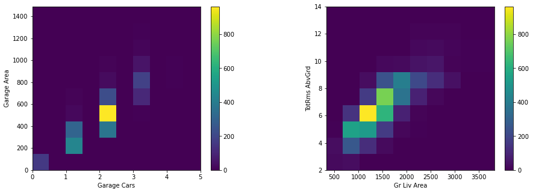

```python
plt.rc("grid", linewidth=0.05)
fig, axes = plt.subplots(1, 2, figsize=(15,5))
fig.subplots_adjust(hspace=0.5, wspace=0.4)
h1 = axes[0].hist2d(dataset["Garage Cars"],
                    dataset["Garage Area"],
                    cmap="viridis");
axes[0].set(xlabel="Garage Cars", ylabel="Garage Area")
plt.colorbar(h1[3], ax=axes[0]);
h2 = axes[1].hist2d(dataset["Gr Liv Area"],
                    dataset["TotRms AbvGrd"],
                    cmap="viridis");
axes[1].set(xlabel="Gr Liv Area", ylabel="TotRms AbvGrd")
plt.colorbar(h1[3], ax=axes[1]);
plt.rc("grid", linewidth=0.25)
```

We can see the strong correlation between each pair. For Garage Cars and Garage Area, we see that the highest concentration of data is when Garage Cars is 2 and Garage Area is approximately between 450 and 600 ft2. For Gr Liv Area and TotRms AbvGrd, we notice that the highest concentration is when Garage Liv Area is roughly between 800 and 2000 ft2 and TotRms AbvGrd is 6.

Negative Correlation When we plotted the heatmap, we also discovered a significant negative correlation between Bsmt Unf SF and BsmtFin SF 1, and between Bsmt Unf SF and Bsmt Full Bath. We also want to visualize these correlations. Let us see the distribution of these variables first:

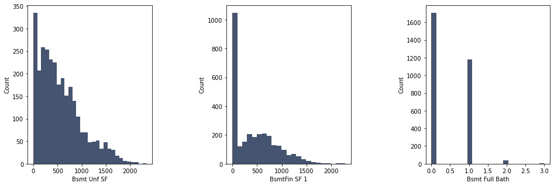

```python
fig, axes = plt.subplots(1, 3, figsize=(16,5))
fig.subplots_adjust(hspace=0.5, wspace=0.6)
for ax, v in zip(axes.flat, ["Bsmt Unf SF", "BsmtFin SF 1", "Bsmt Full Bath"]):
    sns.distplot(dataset[v], kde=False, color="#172B4D",
                 hist_kws={"alpha": 0.8}, ax=ax);
    ax.set(ylabel="Count")
```

Now, we visualize the relationship between each pair using scatter plots:

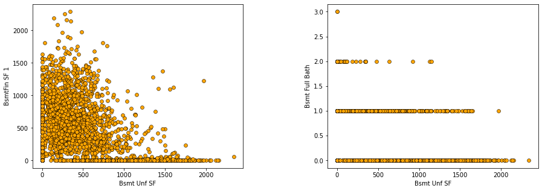

```python
fig, axes = plt.subplots(1, 2, figsize=(15,5))
fig.subplots_adjust(hspace=0.5, wspace=0.4)
axes[0].scatter(dataset["Bsmt Unf SF"], dataset["BsmtFin SF 1"],
                color="orange", edgecolors="#000000", linewidths=0.5);
axes[0].set(xlabel="Bsmt Unf SF", ylabel="BsmtFin SF 1");
axes[1].scatter(dataset["Bsmt Unf SF"], dataset["Bsmt Full Bath"],
                color="orange", edgecolors="#000000", linewidths=0.5);
axes[1].set(xlabel="Bsmt Unf SF", ylabel="Bsmt Full Bath");
```

From the plots, we can see the negative correlation between each pair of these variables.

We will use the information we got from exploratory data analysis in this section, we will use it in feature engineering in the next section.

Feature Engineering In this section, we will use the insights from Exploratory Data Analysis section to engineer the features of our dataset.

Creating New Derived Features

Firstly, we noticed a high positive correlation between the target variable SalePrice and each of Overall Qual and Gr Liv Area. This gives an indication that the latter two features are very important in predicting the sale price. So, we will create polynomial features out of these features: For each one of these features, we will derive a feature whose values are the squares of original values, and another feature whose values are the cubes of original values. Moreover, we will create a feature whose values are the product of our two features values:

```python
for f in ["Overall Qual", "Gr Liv Area"]:
    dataset[f + "_p2"] = dataset[f] ** 2
    dataset[f + "_p3"] = dataset[f] ** 3
dataset["OverallQual_GrLivArea"] = \
    dataset["Overall Qual"] * dataset["Gr Liv Area"]
```

Also, we noticed that there are some predictor features that are highly correlated with each other. To avoid the Multicollinearity problem, we will delete one feature from each pair of highly correlated predictors. We have two pairs: the first consists of Garage Cars and Garage Area, and the other consists of Gr Liv Area and TotRms AbvGrd. For the first pair, we will remove Garage Cars feature; from the second pair, we will remove TotRms AbvGrd feature:

```python
dataset.drop(["Garage Cars", "TotRms AbvGrd"], axis=1, inplace=True)
```

Dealing with Ordinal Variables

There are some ordinal features in our dataset. For example, the Bsmt Cond feature has the following possible values:

```python
print("Unique values in 'Bsmt Cond' column:")
print(dataset['Bsmt Cond'].unique().tolist())
```

```
Unique values in 'Bsmt Cond' column:
['Gd', 'TA', 'No Basement', 'Po', 'Fa', 'Ex']
```

Where "Gd" means "Good", "TA" means "Typical", "Po" means "Poor", "Fa" means "Fair", and "Ex" means "Excellent" according to the dataset documentation. But the problem is that machine learning models will not know that this feature represents a ranking; it will be treated as other categorical features. So to solve this issue, we will map each one of the possible values of this feature to a number. We will map "No Basement" to 0, "Po" to 1, "Fa" to 2, "TA" to 3, "Gd" to 4, and "Ex" to 5.

The ordinal features in the dataset are: Exter Qual, Exter Cond, Bsmt Qual, Bsmt Cond, Bsmt Exposure, BsmtFin Type 1, BsmtFin Type 2, Heating QC, Central Air, Kitchen Qual, Functional, Fireplace Qu, GarageFinish, Garage Qual, Garage Cond, Pool QC, Land Slope and Fence. We will map the values of each of them to corresponding numbers as described for Bsmt Cond above and in accordance with the dataset documentation:

```python
mp = {'Ex':4,'Gd':3,'TA':2,'Fa':1,'Po':0}
dataset['Exter Qual'] = dataset['Exter Qual'].map(mp)
dataset['Exter Cond'] = dataset['Exter Cond'].map(mp)
dataset['Heating QC'] = dataset['Heating QC'].map(mp)
dataset['Kitchen Qual'] = dataset['Kitchen Qual'].map(mp)

mp = {'Ex':5,'Gd':4,'TA':3,'Fa':2,'Po':1,'No Basement':0}
dataset['Bsmt Qual'] = dataset['Bsmt Qual'].map(mp)
dataset['Bsmt Cond'] = dataset['Bsmt Cond'].map(mp)
dataset['Bsmt Exposure'] = dataset['Bsmt Exposure'].map(
    {'Gd':4,'Av':3,'Mn':2,'No':1,'No Basement':0})

mp = {'GLQ':6,'ALQ':5,'BLQ':4,'Rec':3,'LwQ':2,'Unf':1,'No Basement':0}
dataset['BsmtFin Type 1'] = dataset['BsmtFin Type 1'].map(mp)
dataset['BsmtFin Type 2'] = dataset['BsmtFin Type 2'].map(mp)

dataset['Central Air'] = dataset['Central Air'].map({'Y':1,'N':0})
dataset['Functional'] = dataset['Functional'].map(
    {'Typ':7,'Min1':6,'Min2':5,'Mod':4,'Maj1':3,
     'Maj2':2,'Sev':1,'Sal':0})
dataset['Fireplace Qu'] = dataset['Fireplace Qu'].map(
    {'Ex':5,'Gd':4,'TA':3,'Fa':2,'Po':1,'No Fireplace':0})
dataset['Garage Finish'] = dataset['Garage Finish'].map(
    {'Fin':3,'RFn':2,'Unf':1,'No Garage':0})
dataset['Garage Qual'] = dataset['Garage Qual'].map(
    {'Ex':5,'Gd':4,'TA':3,'Fa':2,'Po':1,'No Garage':0})
dataset['Garage Cond'] = dataset['Garage Cond'].map(
    {'Ex':5,'Gd':4,'TA':3,'Fa':2,'Po':1,'No Garage':0})
dataset['Pool QC'] = dataset['Pool QC'].map(
    {'Ex':4,'Gd':3,'TA':2,'Fa':1,'No Pool':0})
dataset['Land Slope'] = dataset['Land Slope'].map(
    {'Sev': 2, 'Mod': 1, 'Gtl': 0})
dataset['Fence'] = dataset['Fence'].map(
    {'GdPrv':4,'MnPrv':3,'GdWo':2,'MnWw':1,'No Fence':0})
```

One-Hot Encoding For Categorical Features

Machine learning models accept only numbers as input, and since our dataset contains categorical features, we need to encode them in order for our dataset to be suitable for modeling. We will encode our categorical features using one-hot encoding technique which transforms the categorical variable into a number of binary variables based on the number of unique categories in the categorical variable; each of the resulting binary variables has only 0 and 1 as its possible values. Pandas package provides a convenient function get_dummies() that can be used for performing one-hot encoding on our dataset.

To see what will happen to our dataset, let us take for example the variable Paved Drive which indicates how the driveway is paved. It has three possible values: Y which means for "Paved", P which means "Partial Pavement", and N which means "Dirt/Gravel". Let us take a look at Paved Drive value for the first few rows in our dataset:

```python
dataset[['Paved Drive']].head()
```

|  | Paved Drive |
| --- | --- |
| 0 | P |
| 1 | Y |
| 2 | Y |
| 3 | Y |
| 4 | Y |

```python
dataset = pd.get_dummies(dataset)
```

```python
pavedDrive_oneHot = [c for c in dataset.columns if c.startswith("Paved")]
dataset[pavedDrive_oneHot].head()
```

|  | Paved Drive_N | Paved Drive_P | Paved Drive_Y |
| --- | --- | --- | --- |
| 0 | 0 | 1 | 0 |
| 1 | 0 | 0 | 1 |
| 2 | 0 | 0 | 1 |
| 3 | 0 | 0 | 1 |
| 4 | 0 | 0 | 1 |

We can see for example that a value of P in the original Paved Drive column is converted to 1 in Paved Drive_P and zeros in Paved Drive_N and Paved Drive_Y after one-hot encoding.

All categorical column are converted in the same way.

Now, after we have cleaned and prepared our dataset, it is ready for modeling.

### Model Building

We will build a model using various regression techniques in our to see which will best fit out dataset.

where z is the result of scaling x , μ is the mean of feature F , and s is the standard deviation of F .

```python
scaler = StandardScaler()
# We need to fit the scaler to our data before transformation
dataset.loc[:, dataset.columns != 'SalePrice'] = scaler.fit_transform(
    dataset.loc[:, dataset.columns != 'SalePrice'])
```

```python
#splitting data set
X_train, X_test, y_train, y_test = train_test_split(
    dataset.drop('SalePrice', axis=1), dataset[['SalePrice']],
    test_size=0.25, random_state=3)
```

#### Ridge Regression

```python
Ridge(alpha=1.0, fit_intercept=True, normalize=False, copy_X=True,
      max_iter=None, tol=0.001, solver= 'auto', random_state=None)

parameter_space = {
    "alpha": [1, 10, 100, 290, 500],
    "fit_intercept": [True, False],
    "solver": ['svd', 'cholesky', 'lsqr', 'sparse_cg', 'sag', 'saga'],
}

clf = GridSearchCV(Ridge(random_state=3), parameter_space, n_jobs=4,
                   cv=3, scoring="neg_mean_absolute_error")

clf.fit(X_train, y_train)
print("Best parameters:")
print(clf.best_params_)
```

```
Best parameters:
{'alpha': 290, 'fit_intercept': True, 'solver': 'cholesky'}
```

Now we build our Ridge model with the best parameters found:

```python
ridge_model = Ridge(random_state=3, **clf.best_params_)
ridge_model.fit(X_train, y_train);

y_pred = ridge_model.predict(X_test)
ridge_mae = mean_absolute_error(y_test, y_pred)

print("Ridge MAE =", ridge_mae)
```

```
Ridge MAE = 15270.463549642722
```

#### Elastic Net

```python
ElasticNet(alpha=1.0, l1_ratio=0.5, fit_intercept=True, normalize=False,
           precompute=False, max_iter=1000, copy_X=True, tol=0.0001,
           warm_start=False, positive=False, random_state=None, selection='cyclic')

parameter_space = {
    "alpha": [1, 10, 100, 280, 500],
    "l1_ratio": [0.5, 1],
    "fit_intercept": [True, False],
}

clf = GridSearchCV(ElasticNet(random_state=3), parameter_space,
                   n_jobs=4, cv=3, scoring="neg_mean_absolute_error")

clf.fit(X_train, y_train)
print("Best parameters:")
print(clf.best_params_)
```

```
Best parameters:
{'alpha': 280, 'fit_intercept': True, 'l1_ratio': 1}
```

```python
elasticNet_model = ElasticNet(random_state=3, **clf.best_params_)

elasticNet_model.fit(X_train, y_train);
y_pred = elasticNet_model.predict(X_test)
elasticNet_mae = mean_absolute_error(y_test, y_pred)
print("Elastic Net MAE =", elasticNet_mae)
```

```
Elastic Net MAE = 14767.909819336588
```

#### Decision Tree

```python
DecisionTreeRegressor(criterion='mse', splitter='best', max_depth=None,
                      min_samples_split=2, min_samples_leaf=1,
                      min_weight_fraction_leaf=0.0, max_features=None,
                      random_state=None, max_leaf_nodes=None, min_impurity_decrease=0.0,
                      min_impurity_split=None)


parameter_space = \
    {
        "criterion": ["mse", "friedman_mse", "mae"],
        "min_samples_split": [5, 18, 29, 50],
        "min_samples_leaf": [3, 7, 15, 25],
        "max_features": [20, 50, 150, 200, X_train.shape[1]],
    }

clf = GridSearchCV(DecisionTreeRegressor(random_state=3), parameter_space,
                   cv=3, scoring="neg_mean_absolute_error", n_jobs=4)

clf.fit(X_train, y_train)
print("Best parameters:")
print(clf.best_params_)
```

```
Best parameters:
{'criterion': 'mse', 'max_features': 242, 'min_samples_leaf': 7, 'min_samples_split': 18}
```

Now we build our Decision Tree model with the best parameters found:

```python
dt_model = DecisionTreeRegressor(**clf.best_params_)
dt_model.fit(X_train, y_train);
y_pred = dt_model.predict(X_test)
dt_mae = mean_absolute_error(y_test, y_pred)
print("Decision Tree MAE =", dt_mae)
```

```
Decision Tree MAE = 20873.949425979506
```

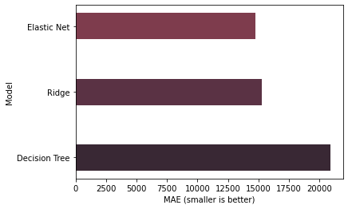

```python
x = ['Decision Tree', 'Ridge',
     'Elastic Net']
y = [20873.95, 15270.46, 14767.91]
colors = ["#392834", "#5a3244", "#7e3c4d", "#a1484f",
          "#c05949", "#d86f3d", "#e88b2b", "#edab06"]
fig, ax = plt.subplots()
plt.barh(y=range(len(x)), tick_label=x, width=y, height=0.4, color=colors);
ax.set(xlabel="MAE (smaller is better)", ylabel="Model");
```

#### Performance Interpretation

Performance Interpretation We chose the mean absolute error (MAE) as our performance metric to evaluate and compare models. MAE presents a value that is easy to understand; it shows the average value of model error. For example, for our Elastic Net model, its MAE is 14767.91 which means that on average, Elastic Net will predict a value that is bigger or smaller than the true value by 14767.91. Now to understand how good this MAE is, we need to know the range and distribution of the data. In our case, we need to see the values of the target variable SalePrice which contains the actual house prices. Let's see the violin plot, box plot, and histogram of SalePrice in our dataset:

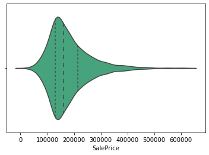

```python
sns.violinplot(x=dataset['SalePrice'], inner="quartile", color="#36B37E");
```

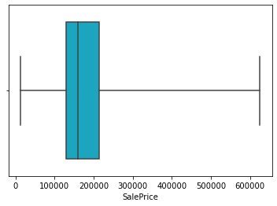

```python
sns.boxplot(dataset['SalePrice'], whis=10, color="#00B8D9");
```

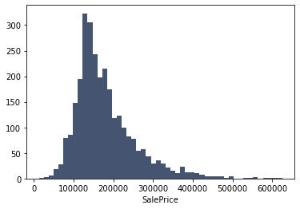

```python
sns.distplot(dataset['SalePrice'], kde=False,
             color="#172B4D", hist_kws={"alpha": 0.8});
```

```python
y_train.describe(include=[np.number])
```

|  | SalePrice |
| --- | --- |
| count | 2193.000000 |
| mean | 179846.689466 |
| std | 79729.375730 |
| min | 12789.000000 |
| 25% | 128500.000000 |
| 50% | 159895.000000 |
| 75% | 214000.000000 |
| max | 625000.000000 |

## Conclusion

Conclusion In this paper, we built serveral regression models to predict the price of some house given some of the house features. We eveluated and compared each model to determine the one with highest performance. In this paper, we followed the data science process starting with importing the data, then cleaning and preprocessing the data, followed by exploring the data and building models, then evaluating the results and communicating them with visualizations.